# TITLE Sujay Gandhi

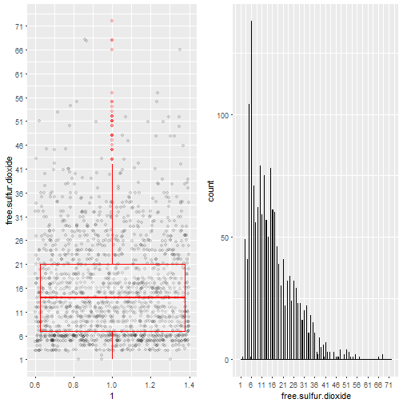

> Free Sulphur Dioxide is postively skewed and we can see some outliers in the data. Highest peak we see is around 6 and then there are few fluctuations in the value.

```
##    Min. 1st Qu.  Median    Mean 3rd Qu.    Max.
##    6.00   22.00   38.00   46.47   62.00  289.00
```

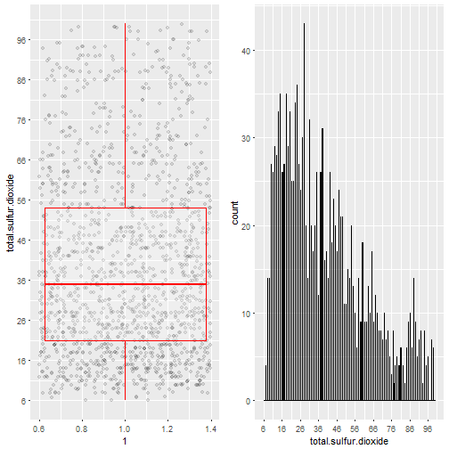

> total Sulphur Dioxide follows a similar pattern to the Free sulphur Dioxide.

```
##    Min. 1st Qu.  Median    Mean 3rd Qu.    Max.
##   2.740   3.210   3.310   3.311   3.400   4.010
```

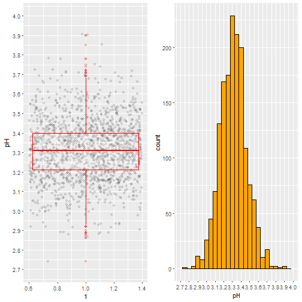

> We can see here majority of the samples have pH value between 3.15 qand 3.4. pH variable has a normal distribution.

```
##    Min. 1st Qu.  Median    Mean 3rd Qu.    Max.
##  0.3300  0.5500  0.6200  0.6581  0.7300  2.0000
```

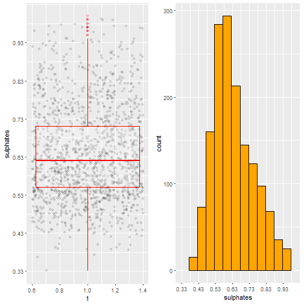

> Sulphates aslo distribute a postively skewed distribution like Total and Free sulphur dioxide.

```
##    Min. 1st Qu.  Median    Mean 3rd Qu.    Max.
##    8.40    9.50   10.20   10.42   11.10   14.90
```

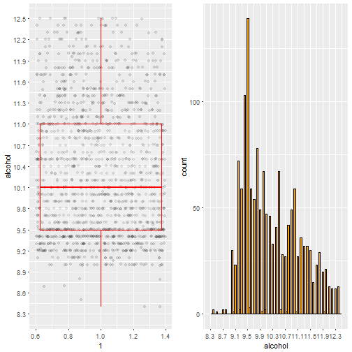

> Alcohol also follows a skewed distribution but here the skewness is less than that of Chlorides or Residual Sugars.

```
##    Min. 1st Qu.  Median    Mean 3rd Qu.    Max.
##  0.9901  0.9956  0.9968  0.9967  0.9978  1.0037
```

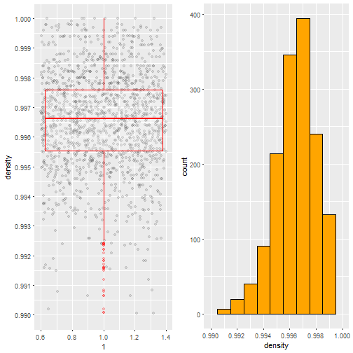

> Density also looks like a normal distribution.

# Univariate Analysis

### What is the structure of your dataset?

> I can the dataset has overall 1599 observations with 13 variable. I have created two additional variables. Total acidity is sum of fixed and volatile acidity. Rating Bucket is created looking at the quality of the wine. Here I can majority of observations has wine with quality 5 and 6 which we can consider as average. This raises a question whether the dataset is complete.

### What is/are the main feature(s) of interest in your dataset?

> My interest is mostly in figuring out which variables contribute in determining the quality of the wine.

### What other features in the dataset do you think will help support your \

investigation into your feature(s) of interest?

> I think quality of the wine will depend on pH and pH will have relation with fixed and volatile acidity. I will be also interested in seeing the effect of sugar and density on the quality.

> pH and Density had a fairly good normal distribution, but citrix acid is nearly an uniform distribution. Fixed and volatile acidity, total and free sulfur dioxides, alcohol and sulphates seem to be postively skewed with the outliers present.

# Bivariate Plots Section

```
##
##  Pearson's product-moment correlation
##
## data:  wine$fixed.acidity and as.numeric(wine$quality)
## t = 4.996, df = 1597, p-value = 6.496e-07
## alternative hypothesis: true correlation is not equal to 0
## 95 percent confidence interval:
##  0.07548957 0.17202667
## sample estimates:
##       cor
## 0.1240516
```

```
##
##  Pearson's product-moment correlation
##
## data:  wine$volatile.acidity and as.numeric(wine$quality)
## t = -16.954, df = 1597, p-value < 2.2e-16
## alternative hypothesis: true correlation is not equal to 0
## 95 percent confidence interval:
##  -0.4313210 -0.3482032
## sample estimates:
##        cor
## -0.3905578
```

```
##
##  Pearson's product-moment correlation
##
## data:  wine$residual.sugar and as.numeric(wine$quality)
## t = 0.5488, df = 1597, p-value = 0.5832
## alternative hypothesis: true correlation is not equal to 0
## 95 percent confidence interval:
##  -0.03531327  0.06271056
## sample estimates:
##        cor
## 0.01373164
```

```
##
##  Pearson's product-moment correlation
##
## data:  wine$free.sulfur.dioxide and as.numeric(wine$quality)
## t = -2.0269, df = 1597, p-value = 0.04283
## alternative hypothesis: true correlation is not equal to 0
## 95 percent confidence interval:
##  -0.099430290 -0.001638987
## sample estimates:
##         cor
## -0.05065606
```

```
##
##  Pearson's product-moment correlation
##
## data:  wine$total.sulfur.dioxide and as.numeric(wine$quality)
## t = -7.5271, df = 1597, p-value = 8.622e-14
## alternative hypothesis: true correlation is not equal to 0
## 95 percent confidence interval:
##  -0.2320162 -0.1373252
## sample estimates:
##        cor
## -0.1851003
```

```
##
##  Pearson's product-moment correlation
##
## data:  wine$alcohol and as.numeric(wine$quality)
## t = 21.639, df = 1597, p-value < 2.2e-16
## alternative hypothesis: true correlation is not equal to 0
## 95 percent confidence interval:
##  0.4373540 0.5132081
## sample estimates:
##       cor
## 0.4761663
```

```
##
##  Pearson's product-moment correlation
##
## data:  wine$pH and as.numeric(wine$quality)
## t = -2.3109, df = 1597, p-value = 0.02096
## alternative hypothesis: true correlation is not equal to 0
## 95 percent confidence interval:
##  -0.106451268 -0.008734972
## sample estimates:
##         cor
## -0.05773139
```

```
##
##  Pearson's product-moment correlation
##
## data:  wine$density and as.numeric(wine$quality)
## t = -7.0997, df = 1597, p-value = 1.875e-12
## alternative hypothesis: true correlation is not equal to 0
## 95 percent confidence interval:
##  -0.2220365 -0.1269870
## sample estimates:
##        cor
## -0.1749192
```

```
##
##  Pearson's product-moment correlation
##
## data:  wine$total.acidity and as.numeric(wine$quality)
## t = 3.4378, df = 1597, p-value = 0.0006015
## alternative hypothesis: true correlation is not equal to 0
## 95 percent confidence interval:
##  0.03684298 0.13416675
## sample estimates:
##        cor
## 0.08570932
```

```
##
##  Pearson's product-moment correlation
##
## data:  wine$sulphates and as.numeric(wine$quality)
## t = 10.38, df = 1597, p-value < 2.2e-16
## alternative hypothesis: true correlation is not equal to 0
## 95 percent confidence interval:
##  0.2049011 0.2967610
## sample estimates:
##       cor
## 0.2513971
```

> in the initial analysis I am just trying to see if there is any relation of variables with the wine quality. I can see that volatile acidity and alcohol are strongly related with quality.Variables such as sulphate and density are also loosely related to quality.

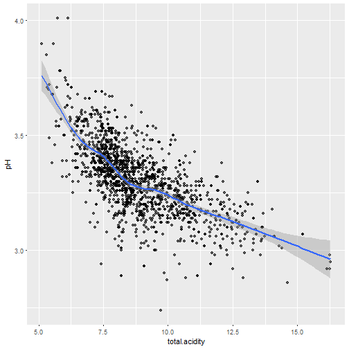

> Looking at the relation between total acidity and pH we can easily see that there is negative correlation here which is expected. Lets dig further to see if both volatiel and fixed acidity have the same releation with pH.

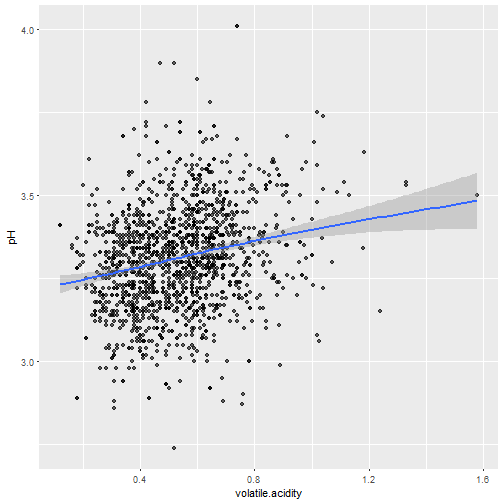

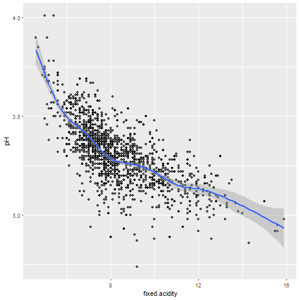

> Fixed acidity has a negative correlation as similar to total acidity but the relation between volatile acidity and pH is opposite which is strange as we expect pH value to go down as acidity increases.

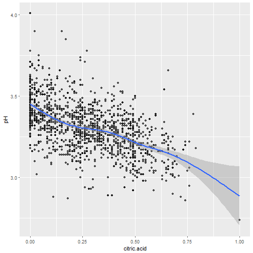

> pH also has a negative correlation with citric acid.

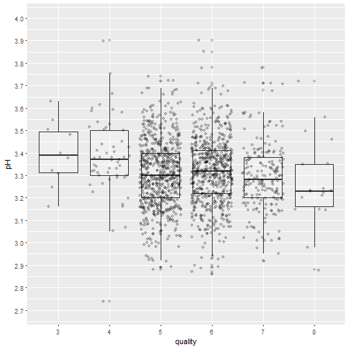

> In graph between pH and quality we can see that there is a silight negative correlation.We can confirm this by the total.acidity relation with pH.

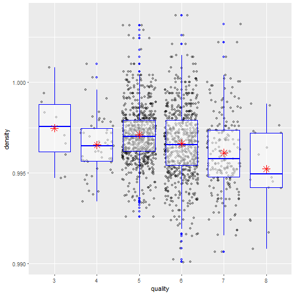

> Better wines seems to have lower densities. This can be a factor but we may also have to look at the relation between density and some other strong related variables such as volatile.acidity and alcohol.

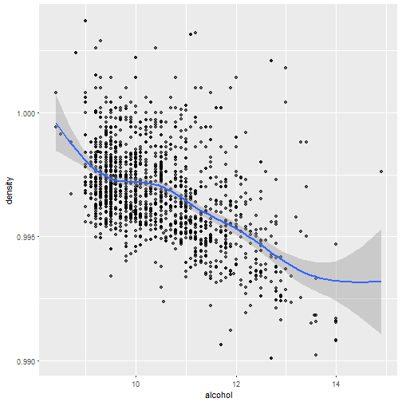

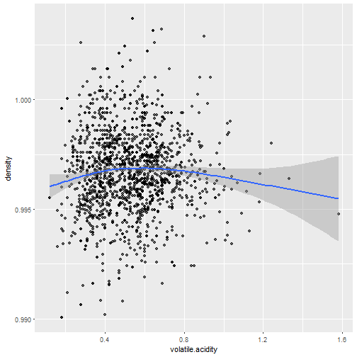

> Density has a strong neagative relation with alcohol. That explains the relation with quality.

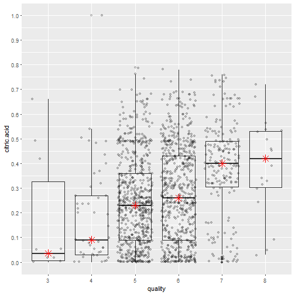

> We can also see there is slight positive correlation in citric acid and quality. We can see this also from pH and citric acid plot.

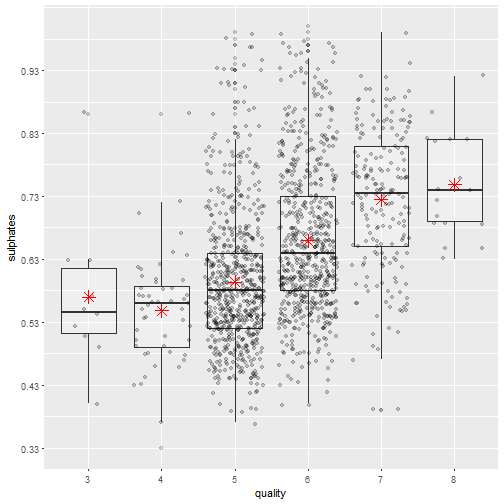

> Sulphate have a positive correlation with the quality. This is definitely a factor impacting quality.

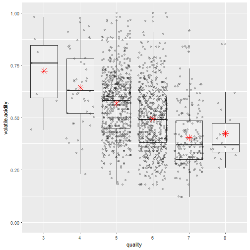

> As we saw from correlation test we can see here again volatile acidity and quality are highly correlated.

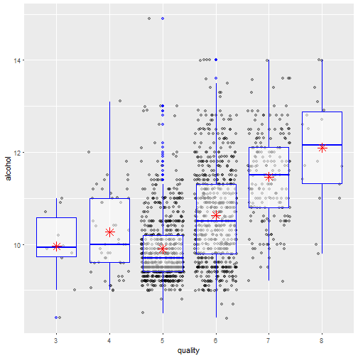

> As we saw from correlation test we can see here again alcohol and quality are highly correlated.

# Bivariate Analysis

### Talk about some of the relationships you observed in this part of the \

investigation. How did the feature(s) of interest vary with other features in \ the dataset?

### Did you observe any interesting relationships between the other features \

(not the main feature(s) of interest)?

> One thing I found which was bit strange was the relation between pH value and Volatile acidity.

### What was the strongest relationship you found?

> Relation in Volatile acidity and quality is strong. Also the relation in Alcohol and quality is also quite strong.

# Multivariate Plots Section

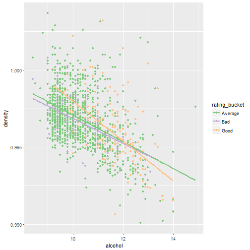

> From the bivariate analysis we figured that the alcohol has a strong relation with the quality. So to get more understanding of this I have created a rating bucket for quality. To investigate further lets look at denstity as additional variable. From the above plot we can see that there is not much of different in ratings due to addition of density. Hence we can say the results we saw earlier with density and quality of wine were due to alcohol.

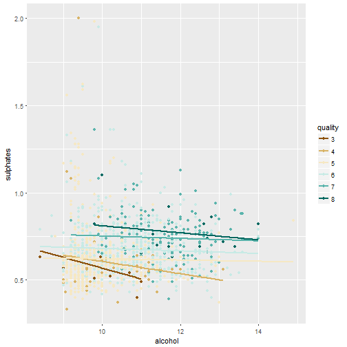

> From bivariate analysis another variable we found which had a relation with quality was sulphates. Looking at the above plot we can say that with higher sulphate and alcohol values quality of the wine goes up.

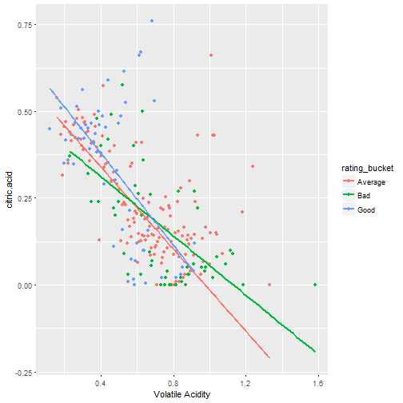

> From the analysis we know the second factor which impacts the quality is volatile acidity. We also saw that Citric acid and pH has some imapct on quality. Lets look at the citric acid now. From the above plot we can see that Higher value of citric acid and lower value of Volatile acidity seems to create wine with average or good quality. So we can say that citric acid is one of the factors to have impact on quality of wine.

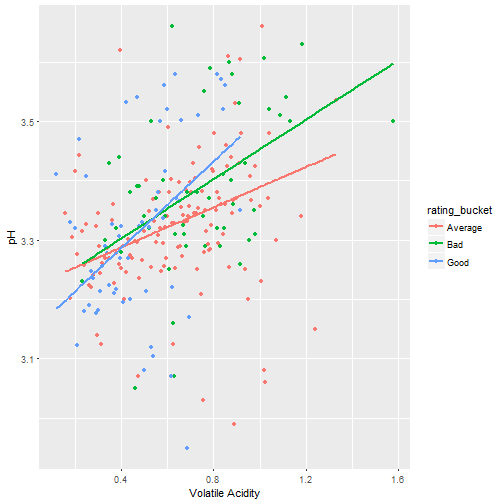

```
##
## Calls:
## m1: lm(formula = as.numeric(quality) ~ alcohol, data = wine)
## m2: lm(formula = as.numeric(quality) ~ alcohol + sulphates, data = wine)
## m3: lm(formula = as.numeric(quality) ~ alcohol + sulphates + volatile.acidity,
##     data = wine)
## m4: lm(formula = as.numeric(quality) ~ alcohol + sulphates + volatile.acidity +
##     citric.acid, data = wine)
## m5: lm(formula = as.numeric(quality) ~ alcohol + sulphates + volatile.acidity +
##     citric.acid + pH, data = wine)
##
## ==========================================================================================
##                          m1            m2            m3            m4            m5
## ------------------------------------------------------------------------------------------
##   (Intercept)          -0.125        -0.625***      0.611**       0.646**       2.112***
##                        (0.175)       (0.177)       (0.196)       (0.201)       (0.459)
##   alcohol               0.361***      0.346***      0.309***      0.309***      0.327***
##                        (0.017)       (0.016)       (0.016)       (0.016)       (0.017)
##   sulphates                           0.994***      0.679***      0.696***      0.673***
##                                      (0.102)       (0.101)       (0.103)       (0.103)
##   volatile.acidity                                 -1.221***     -1.265***     -1.284***
##                                                    (0.097)       (0.113)       (0.112)
##   citric.acid                                                    -0.079        -0.297*
##                                                                  (0.104)       (0.120)
##   pH                                                                           -0.475***
##                                                                                (0.134)
## ------------------------------------------------------------------------------------------
##   R-squared             0.227         0.270         0.336         0.336         0.341
##   adj. R-squared        0.226         0.269         0.335         0.334         0.339
##   sigma                 0.710         0.690         0.659         0.659         0.656
##   F                   468.267       294.988       268.912       201.777       165.112
##   p                     0.000         0.000         0.000         0.000         0.000
##   Log-likelihood    -1721.057     -1675.142     -1599.384     -1599.093     -1592.801
##   Deviance            805.870       760.894       692.105       691.852       686.429
##   AIC                3448.114      3358.284      3208.768      3210.186      3199.602
##   BIC                3464.245      3379.793      3235.654      3242.448      3237.242
##   N                  1599          1599          1599          1599          1599
## ==========================================================================================
```

> After doing this analysis lets create a Linear model with the variables we identified as the ones who have an impact on wine quality. I have considerd 5 variables, alcohol, sulpahe, volatile acidity,citric acid and pH.

```
##        fit      lwr      upr
## 1 20.09067 5.533839 72.93944
```

# Multivariate Analysis

### Talk about some of the relationships you observed in this part of the \

investigation. Were there features that strengthened each other in terms of \ looking at your feature(s) of interest?

> From this we can see that higher sulphate and Higher alcohol content creates a better wine. We can also see that citric acid even were loosely correlated has an impact on wine quality.

### Were there any interesting or surprising interactions between features?

### OPTIONAL: Did you create any models with your dataset? Discuss the \

strengths and limitations of your model.

# Final Plots and Summary

### Plot One

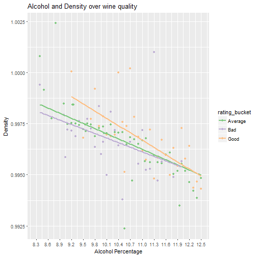

### Description One

> In this plot we can see effect of alcohol and Density on the quality of Wine. We can see as the alcohol percentages are increasing quality of wine is also increasing. Density does not have much effect without the alcohol. Hence this plot proves the relation between density and quality of wine is due to Alcohol.

### Plot Two

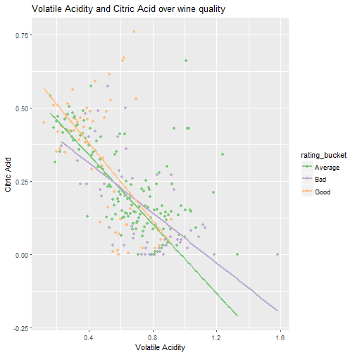

### Description Two

> In this plot we can see the effect of Citric acid and Volatile Acidity on the wine quality. We can see with higher values of citric acid and lower values of volatile acidity we can see the quality of the wine is better.

### Plot Three

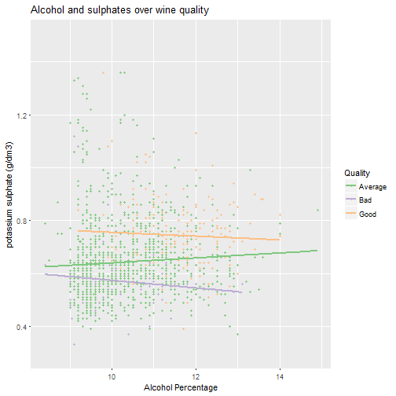

### Description Three

> In this plot, we see that the best quality wines have high values for both Alcohol percentage and Sulphate concentration implying that High alcohol contents and high sulphate concentrations together seem to produce better wines. Although there is a very slight downwards slope maybe because in best quality wines, percentage of alcohol is slightly greater than the concentration of Sulphates.

# Reflection

> There are of course some shortcomings and struggles that I had with this analysis. My linear model can only predict 34.1% of the quality of wine. Given that quality of wine is subjective and there are many things that can make a wine good, it is understandable that my r<sup>2</sup> is low, but naturally, I would prefer a higher value.In the dataset during initial Univariate analysis I found that wine quality is highly concentrated for average rating. This was my concern for my linear model. I think we can not find a correct linear model with this dataset. We will need more observations from the Bad and Good wine quality to help identify the variables having more impact on wine quality. We should have a dataset where the quality of wine has equal distribution.

> For future analysis, I would love to have a dataset, where apart from the wine quality, I would like to have rating system with Human input. We can have ratings from probably 10 people which can give us another insight into the wine quality.